# Assignment 14: Writing a function - Loop

*How to do it?*:

- Open the Rmarkdown file of this assignment (link) in Rstudio.
- Right under each **question**, insert a code chunk (you can use the hotkey `Ctrl + Alt + I` to add a code chunk) and code the solution for the question.
- `Knit` the rmarkdown file (hotkey: `Ctrl + Alt + K`) to export an html.
- Publish the html file to your Githiub Page.

*Submission*: Submit the link on Github of the assignment to Canvas

1. Write the following function. Give examples to test your function.
- Input: a data frame
- Output: a data frame with all the missing of numeric variables replaced by the associated means.

Hint: [Similar function](https://bryantstats.github.io/math421/gganimate/18_writing_functions.html#28)

```r
# Mean Impute function from Assignment 13
library(tidyverse)
mean_impute <- function(x)
{
  if(is.numeric(x))
  {
    # Find mean of x
    mean_of_x <- mean(x, na.rm = TRUE)
    x <- replace_na(x, mean_of_x)
  }
return(x)
}
```

```r
# Function
numeric_impute <- function(d)
{
  for (i in 1:length(d))
  {
      d[[i]] <- mean_impute(d[[i]])
  }
  return(d)
}
```

```r
# Read in Titanic df
df <- read_csv("titanic.csv")
```

```r
# Missings before impute
colSums(is.na(df))
```

```
## PassengerId    Survived      Pclass        Name         Sex         Age
##           0           0           0           0           0         177
##       SibSp       Parch      Ticket        Fare       Cabin    Embarked
##           0           0           0           0         687           2
```

```r
# Example: Titanic
d1 <- numeric_impute(df)
```

```r
colSums(is.na(d1))
```

```
## PassengerId    Survived      Pclass        Name         Sex         Age
##           0           0           0           0           0           0
##       SibSp       Parch      Ticket        Fare       Cabin    Embarked
##           0           0           0           0         687           2
```

2. Write the following function. Give examples to test your function.
- Input: a data frame
- Output: a data frame with all the missing of variables replaced by the associated means (for numeric variables) or modes (for non-numeric variables).

Hint: Use If-statement to combine the function in Problem 1 and the function in [this example](https://bryantstats.github.io/math421/gganimate/18_writing_functions.html#28)

```r
# Mode Impute function
mode_impute <- function(x)
{
  if(!is.numeric(x))
  {
    # Find mean of x
    mode_of_x <- names(sort(-table(x)))[1]
    x <- replace_na(x, mode_of_x)
  }
return(x)
}
```

```r
# Function
impute <- function(d)
{
  for (i in 1:length(d))
  {
    if(is.numeric(d[[i]])){
      d[[i]] <- mean_impute(d[[i]])
    }
    else
      d[[i]] <- mode_impute(d[[i]])
  }
  return(d)
}
```

```r
# Missing values before imputation
colSums(is.na(df))
```

```
## PassengerId    Survived      Pclass        Name         Sex         Age
##           0           0           0           0           0         177
##       SibSp       Parch      Ticket        Fare       Cabin    Embarked
##           0           0           0           0         687           2
```

```r
# Example: Titanic
d2 <- impute(df)
colSums(is.na(d2))
```

```
## PassengerId    Survived      Pclass        Name         Sex         Age
##           0           0           0           0           0           0
##       SibSp       Parch      Ticket        Fare       Cabin    Embarked
##           0           0           0           0           0           0
```

3. Write the following function. Give examples to test your function.
- Input: a data frame
- Output: Bar plots of all non-numeric variables

Hint: [Similar function](https://bryantstats.github.io/math421/gganimate/18_writing_functions.html#33)

```r
# Clean Titanic Dataset
df <- df |> mutate(Survived = factor(Survived),
             Pclass = factor(Pclass),
             Sex = factor(Sex),
             Embarked = factor(Embarked),
             Ticket = factor(Ticket),
             Cabin = factor(Cabin))

df <- df |> drop_na()

df_clean <- df |> select(Survived, Pclass, Sex, Age, SibSp, Parch, Fare, Embarked)
```

```r
# Function
bar_plot <- function(d)
{
  for (i in 1:length(d))
  {
    if (!is.numeric(d[[i]]))
    {
      print(ggplot(d) +
              geom_bar(mapping = aes(x = d[[i]])) +
              labs(x = names(d)[i]))
    }
  }
}
```

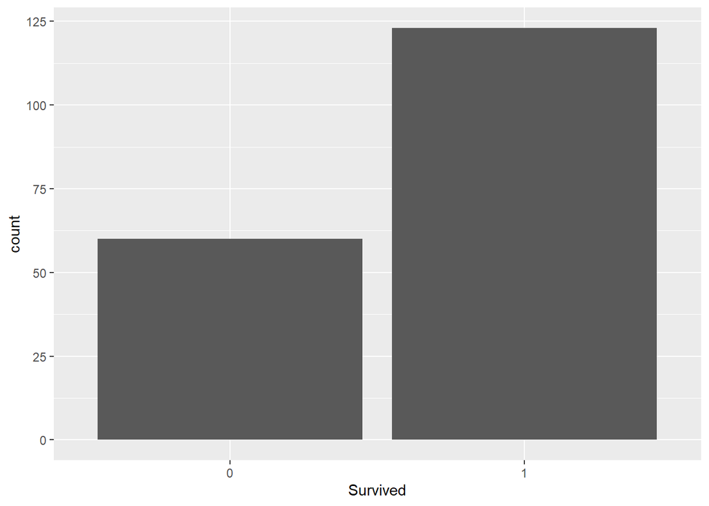

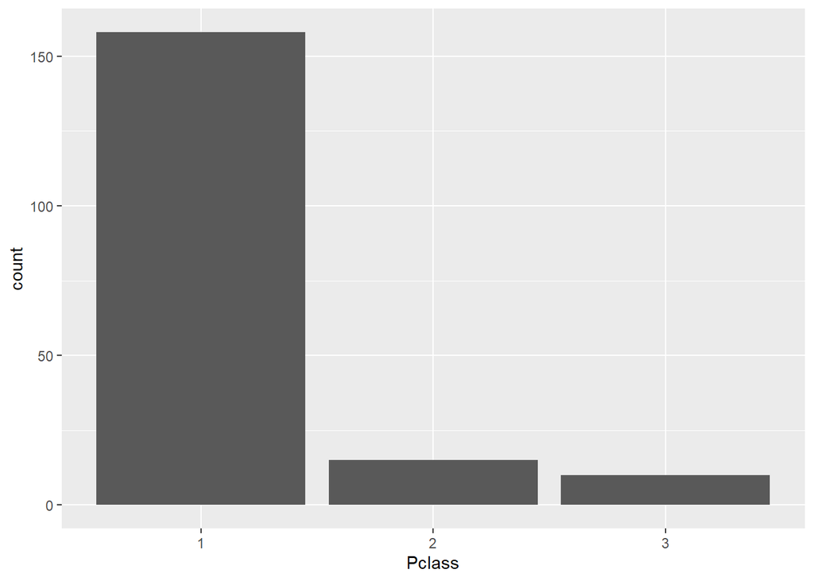

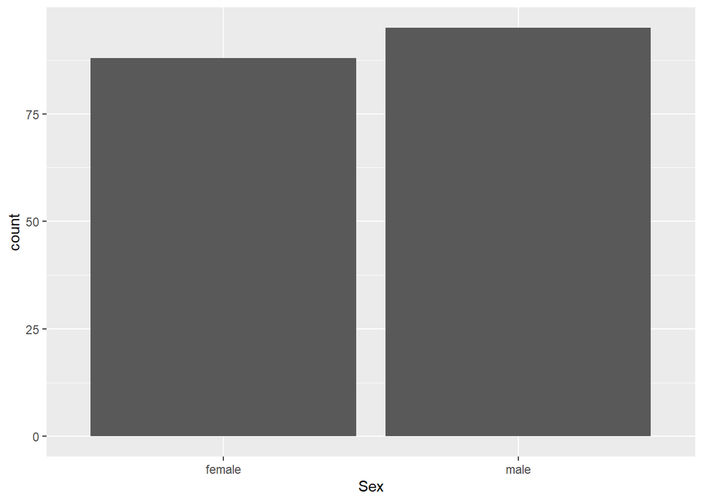

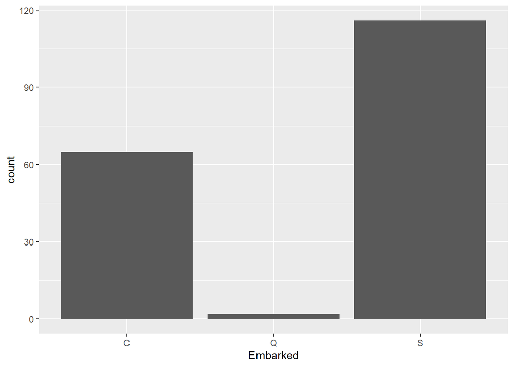

```r
# Example
bar_plot(df_clean)
```

4. Write the following function. Give examples to test your function.
- Input: a data frame
- Output: all possible the bar plots of a non-numeric variable filled by a non-numeric variable.

Hint: [Similar function](https://bryantstats.github.io/math421/gganimate/18_writing_functions.html#40)

```r
# Function
bar_plot2 <- function(d)
{
  l <- length(d)
  for (i in 1:(l-1))
    for (j in (i+1):l)
  {
    if (!is.numeric(d[[i]])& (!is.numeric(d[[j]])))
    {
      print(ggplot(d, aes(x = d[[i]], fill = d[[j]]))+
              geom_bar()+labs(x = names(d)[i], fill = names(d)[j]))
    }
  }
}
```

```r
# Example
bar_plot2(df_clean)
```

[output not shown]

5. Write the following function. Give examples to test your function.
- Input: a data frame
- Output:
  - all possible the bar plots of a non-numeric variable filled by a non-numeric variable.
  - all possible the density plots of a numeric variable colored by a non-numeric variable
  - all possible the scatter plots.

Hint: Combine [this function](https://bryantstats.github.io/math421/gganimate/18_writing_functions.html#37), [this function](https://bryantstats.github.io/math421/gganimate/18_writing_functions.html#40), and the function in Question 4. One way to combine is creating a new function, `quick_plot`, and call these three functions within `quick_plot`.

```r
# Density Plot
density_plot <- function(d)
{
  l <- length(d)
  for (i in 1:(l-1))
    for (j in (i+1):l)
  {
    if (is.numeric(d[[i]])& (!is.numeric(d[[j]])))
    {
      print(ggplot(d, aes(x = d[[i]], color = d[[j]]))+
              geom_density()+labs(x = names(d)[i], color = names(d)[j]))
    }
  }
}
```

```r
# Scatter Plot
scatter_plot <- function(d)
{
  l <- length(d)
  for (i in 1:(l-1))
    for (j in (i+1):l)
  {
    if (is.numeric(d[[i]])&is.numeric(d[[j]]))
    {
      print(ggplot(d, aes(x = d[[i]], y = d[[j]]))+
              geom_point()+
              labs(x = names(d)[i], y = names(d)[j]))
    }
  }
}
```

```r
# Main Function
quick_plot <- function(d)
{
  l <- length(d)
  for (i in 1:(l-1))
    for (j in (i+1):l)
  {
      if (!is.numeric(d[[i]])& (!is.numeric(d[[j]])))
      {
        bar_plot2(d)
      }
      else if (is.numeric(d[[i]])& (!is.numeric(d[[j]])))
      {
        density_plot(d)
      }
      else if (is.numeric(d[[i]])&is.numeric(d[[j]]))
      {
        scatter_plot(d)
      }
    }
}
```

```r
quick_plot(df_clean)
```

[output not shown]